# Checks on the Bayesian Hierarchical Models

Kristian Brock

16 September, 2019

```r
# This script in the root of the project loads the datasets
source('../../../Load.R')

library(brms)
library(ggplot2)
```

## DLT Model

```r
dlt_mod <- readRDS('dlt_mod.rds')
```

```r
dlt_mod
```

```
 Family: binomial
  Links: mu = logit
Formula: Events | trials(n) ~ 1 + FixedDoseChemo + (1 + DoseLevel | AnalysisSeriesId) + (1 + DoseLevel | DoseVaryingTreatmentType)
   Data: dlt %>% left_join(studies, by = "Study") (Number of observations: 637)
Samples: 4 chains, each with iter = 3000; warmup = 1500; thin = 1;
         total post-warmup samples = 6000

Group-Level Effects:
~AnalysisSeriesId (Number of levels: 154)
                         Estimate Est.Error l-95% CI u-95% CI Eff.Sample Rhat
sd(Intercept)                0.87      0.11     0.66     1.10       2367 1.00
sd(DoseLevel)                0.45      0.10     0.27     0.64       1938 1.00
cor(Intercept,DoseLevel)     0.51      0.22     0.06     0.92       1390 1.00

~DoseVaryingTreatmentType (Number of levels: 15)
                         Estimate Est.Error l-95% CI u-95% CI Eff.Sample Rhat
sd(Intercept)                0.64      0.34     0.10     1.44       1866 1.00
sd(DoseLevel)                0.81      0.26     0.43     1.43       2347 1.00
cor(Intercept,DoseLevel)     0.26      0.52    -0.79     0.98        617 1.00

Population-Level Effects:
               Estimate Est.Error l-95% CI u-95% CI Eff.Sample Rhat
Intercept         -2.64      0.38    -3.45    -1.94        909 1.00
FixedDoseChemo     0.32      0.24    -0.15     0.79       4108 1.00

Samples were drawn using sampling(NUTS). For each parameter, Eff.Sample
is a crude measure of effective sample size, and Rhat is the potential
scale reduction factor on split chains (at convergence, Rhat = 1).
```

Rhats and Eff.Samples look fine. No divergent transitions or violations of max tree-depth are reported.

```
Using 10 posterior samples for ppc type 'dens_overlay' by default.
```

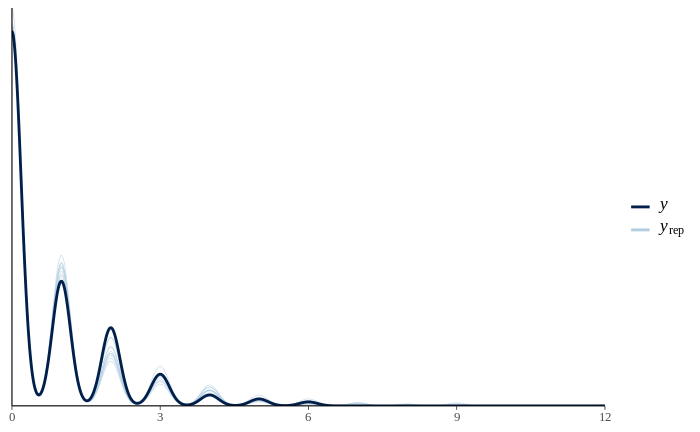

```r
pp_check(dlt_mod)
```

The x-axis is the sampled number of DLTs, conditional on the number of attempts, using all of the DLT series. Posterior samples are a faithful representation of the observed data.

Distribution of series-level intercepts:

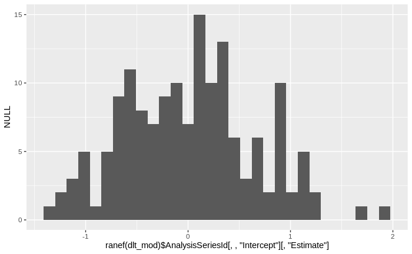

```r
qplot(ranef(dlt_mod)$AnalysisSeriesId[, , 'Intercept'][,'Estimate'],
      geom = 'histogram')
```

Normal enough.

Distribution of series-level gradients for DoseLevel:

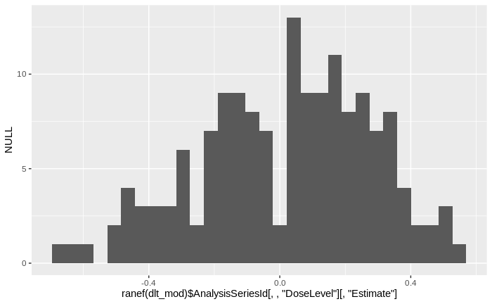

```r
qplot(ranef(dlt_mod)$AnalysisSeriesId[, , 'DoseLevel'][,'Estimate'],
      geom = 'histogram')
```

Bit of a negative skew but not alarmingly non-normal.

Distribution of series-level intercepts:

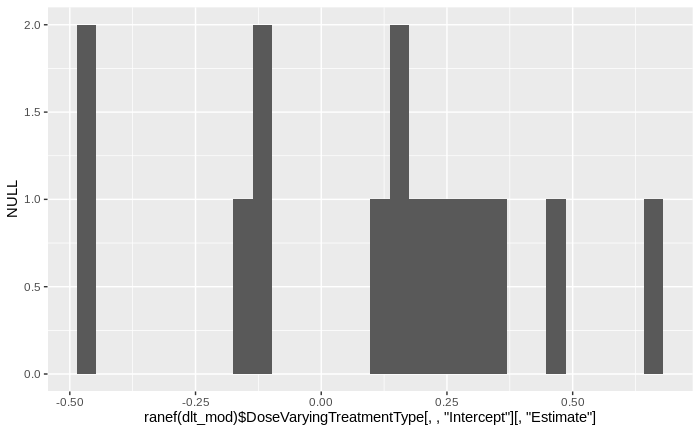

```r
qplot(ranef(dlt_mod)$DoseVaryingTreatmentType[, , 'Intercept'][,'Estimate'],
      geom = 'histogram')
```

There are not many of these but the fit to normal is not persuasive.

Distribution of series-level gradients for DoseLevel:

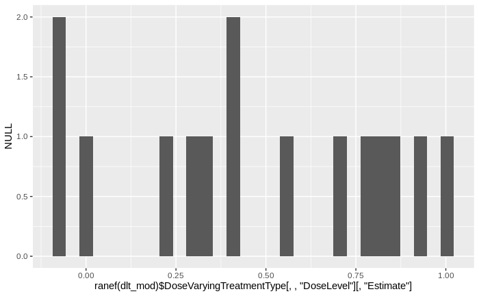

```r
qplot(ranef(dlt_mod)$DoseVaryingTreatmentType[, , 'DoseLevel'][,'Estimate'],
      geom = 'histogram')
```

There are not many of these but the fit to normal is not persuasive.

## Objective Response Model

```r
obj_resp_mod <- readRDS('obj_resp_mod.rds')
```

```r
obj_resp_mod
```

```
 Family: binomial
  Links: mu = logit
Formula: Events | trials(n) ~ 1 + FixedDoseChemo + (1 + DoseLevel | AnalysisSeriesId) + (1 + DoseLevel | DoseVaryingTreatmentType)
   Data: obj_resp %>% left_join(studies, by = "Study") %>%  (Number of observations: 372)
Samples: 4 chains, each with iter = 3000; warmup = 1500; thin = 1;
         total post-warmup samples = 6000

Group-Level Effects:
~AnalysisSeriesId (Number of levels: 93)
                         Estimate Est.Error l-95% CI u-95% CI Eff.Sample Rhat
sd(Intercept)                2.31      0.28     1.83     2.93       1920 1.00
sd(DoseLevel)                0.18      0.11     0.01     0.42       1582 1.00
cor(Intercept,DoseLevel)     0.08      0.48    -0.87     0.91       5746 1.00

~DoseVaryingTreatmentType (Number of levels: 12)
                         Estimate Est.Error l-95% CI u-95% CI Eff.Sample Rhat
sd(Intercept)                1.24      0.76     0.17     3.10       1108 1.00
sd(DoseLevel)                0.26      0.20     0.01     0.75       1910 1.00
cor(Intercept,DoseLevel)     0.02      0.56    -0.94     0.94       2609 1.00

Population-Level Effects:
               Estimate Est.Error l-95% CI u-95% CI Eff.Sample Rhat
Intercept         -3.04      0.62    -4.42    -1.90       2527 1.00
FixedDoseChemo     2.97      0.73     1.58     4.44       1431 1.00

Samples were drawn using sampling(NUTS). For each parameter, Eff.Sample
is a crude measure of effective sample size, and Rhat is the potential
scale reduction factor on split chains (at convergence, Rhat = 1).
```

Rhats and Eff.Samples look fine. No divergent transitions or violations of max tree-depth are reported.

```
Using 10 posterior samples for ppc type 'dens_overlay' by default.
```

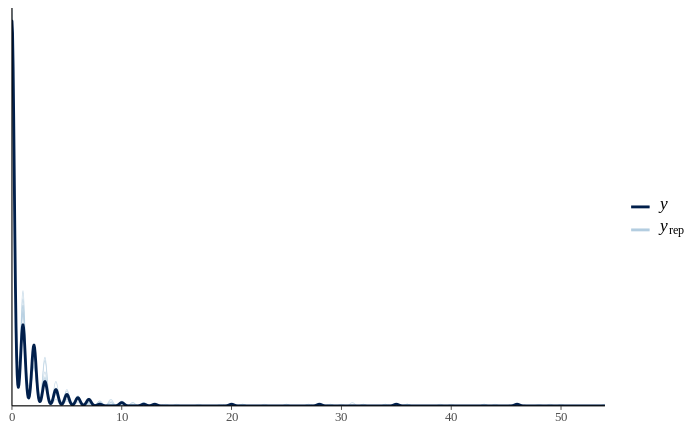

```r
pp_check(obj_resp_mod)
```

The x-axis is the sampled number of responses, conditional on the number of attempts, using all of the response series. Posterior samples are a faithful representation of the observed data.

Distribution of series-level intercepts:

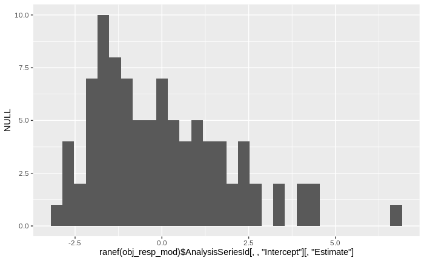

```r
qplot(ranef(obj_resp_mod)$AnalysisSeriesId[, , 'Intercept'][,'Estimate'],
      geom = 'histogram')
```

Kinda normal.

Distribution of series-level gradients for DoseLevel:

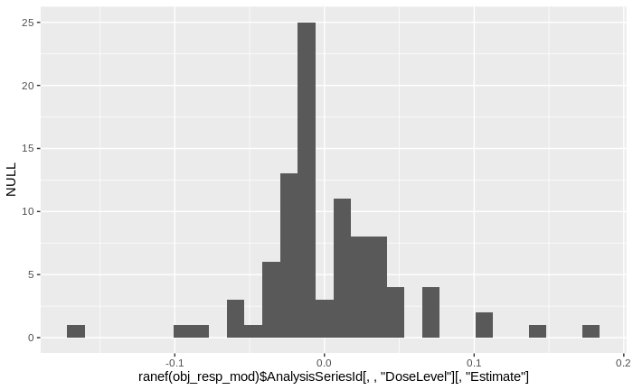

```r
qplot(ranef(obj_resp_mod)$AnalysisSeriesId[, , 'DoseLevel'][,'Estimate'],
      geom = 'histogram')
```

Long tails but not alarmingly non-normal.

Distribution of series-level intercepts:

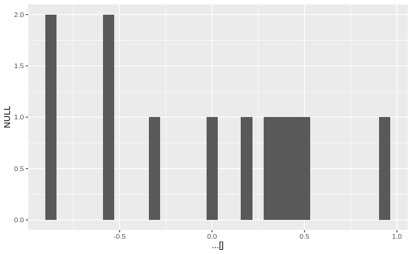

```r
qplot(ranef(obj_resp_mod)$DoseVaryingTreatmentType[, , 'Intercept'][,'Estimate'],
      geom = 'histogram')
```

There are not many of these. There appears to be some central tendency albeit with long negative tail.

Distribution of series-level gradients for DoseLevel:

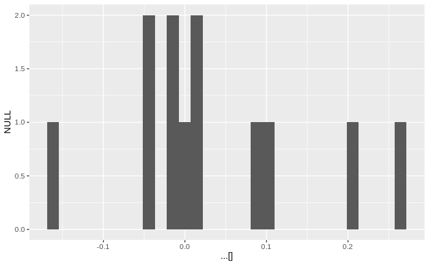

```r
qplot(ranef(obj_resp_mod)$DoseVaryingTreatmentType[, , 'DoseLevel'][,'Estimate'],
      geom = 'histogram')
```

There are not many of these. There appears to be some central tendency and symmetry. Normal is not a poor working model.